# Further exploratory data analysis

Charles

Last compiled on 07 August, 2023

## Introduction

In this script I perform further exploratory data analyses on DNA methylation data from TGCA.

## Load libraries

```r
library(rafalib)
library(coloncancermeth)
data(coloncancermeth)
dim(meth)
dim(pd)
```

## Exploratory data analysis

### Use the methylation profiles to compute a Euclidean distance between each sample.

```r
d <- dist(t(meth))
```

Now use **cmdscale** function.

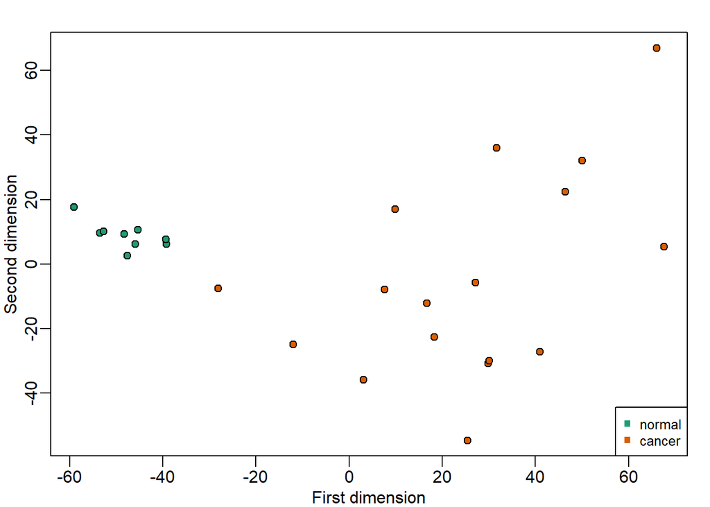

```r
mds <- cmdscale(d)
colnames(mds) <- c("PC1", "PC2")

mypar(1,1)
plot(mds[, "PC1"],
     mds[, "PC2"],
     pch=21,bg=as.numeric(pd$Status),
     xlab = "First dimension",
     ylab = "Second dimension")
legend("bottomright",levels(pd$Status),
       col=seq(along=levels(pd$Status)),pch=15,cex=0.8)
```

The MDS plot shows separation between cancer and normal samples, but only in the first dimension. The second dimension seems to be associated with a large variability within the cancers.

### For each CpG compute p-values for the cancer versus normal comparison using the limma package.

```r
library(limma)
X <- model.matrix(~pd$Status)
fit <- lmFit(meth, X)
eb <- eBayes(fit)
pvals <- eb$p.value[, 2]
q_values <- qvalue::qvalue(pvals)
mean(q_values$qvalues < 0.05)
```

```
## [1] 0.2373412
```

Only 23.73% of CpGs are differentially methylated in tumour vs healthy conditions based on their q values (corrected for multiple hypothesis testing).

```r
Index <- which(q_values$qvalues <= 0.05)
sig_coefs <- eb$coefficients[Index, ]
mean(sig_coefs[, 2] > 0)
```

```
## [1] 0.4106411
```

41% of CpGs that are significantly differentially methylated are more methylated in the tumour compared to healthy samples.

### Determine which of the differentially methylated CpGs are in CpG islands.

```r
library(AnnotationHub)
ah <- AnnotationHub()
cgi <- ah[["AH5086"]] # islands
islands=gr[Index]%over%cgi
hypermethylated=fit$coef[Index,2]>0
prop.table( table(islands,hypermethylated) )
```

```
##        hypermethylated
## islands      FALSE       TRUE
##   FALSE 0.54198487 0.19538843
##   TRUE  0.04737399 0.21525271
```

26.26% of differentially methylated CpGs are in CpG islands.

### Now we will use the bumphunter package to separate the differentially methylated CpGs intro groups.

```r
library(bumphunter)
X <- model.matrix(~pd$Status)
chr <- as.character(seqnames(gr))
res <- bumphunter(meth,
                  X,
                  chr = chr,
                  pos = start(gr),
                  cutoff = 0.1)
head(res$table)
```

```
##         chr     start       end     value     area cluster indexStart indexEnd
## 13439  chr6 133561614 133562776 0.4048535 16.19414  169283     180994   181033
## 13849  chr7  27182493  27185282 0.3023301 15.41883  175222     195992   196042
## 12847  chr6  29520698  29521803 0.3798166 14.81285  163140     158794   158832
## 1561  chr10   8094093   8098005 0.2407042 14.20155   21365     251746   251804
## 2123  chr10 118030848 118034357 0.3844899 11.53470   28533     267198   267227
## 12979  chr6  32063774  32064945 0.2798026 11.19210  163807     165924   165963
##        L clusterL
## 13439 40       43
## 13849 51       53
## 12847 39       40
## 1561  59       60
## 2123  30       30
## 12979 40       73
```

```r
# filtering by zone
dmrs <- res$table[ res$table$L>=3, ]
dmrs <- makeGRangesFromDataFrame(dmrs)
dist_to_island <- distanceToNearest(dmrs, cgi)
mean(dmrs %over%cgi)
```

```
## [1] 0.6105276
```

### Minfi package

It can be used to read, preprocess, analyse data from 450K DNA methylation array.

```r
library(minfi)
# BiocManager::install("IlluminaHumanMethylation450kanno.ilmn12.hg19")
# BiocManager::install("IlluminaHumanMethylation450kmanifest")
```

#### Reading IDAT files

IDAT files are the raw level data for DNA methylation arrays.

```r
list.files("rawdata/")
```

```
##  [1] "5775041065_R01C02_Grn.idat" "5775041065_R01C02_Red.idat"
##  [3] "5775041065_R04C01_Grn.idat" "5775041065_R04C01_Red.idat"
##  [5] "5775041068_R01C02_Grn.idat" "5775041068_R01C02_Red.idat"
##  [7] "5775041068_R04C01_Grn.idat" "5775041068_R04C01_Red.idat"
##  [9] "5775041068_R06C01_Grn.idat" "5775041068_R06C01_Red.idat"
## [11] "5775041084_R01C01_Grn.idat" "5775041084_R01C01_Red.idat"
## [13] "targets.csv"
```

We can see that each file has two colours, red and green. It is important that every pair has the same basename. Changing file names may make package not to work. The target file includes basenames. So you don’t have to construct it.

```r
targets <- read.csv("rawdata/targets.csv", as.is = TRUE)
names(targets)
```

```
##   [1] "X"
##   [2] "bcr_patient_barcode"
##   [3] "bcr_sample_uuid"
##   [4] "bcr_sample_barcode"
##   [5] "NCNNCT_OthMethONSP"
##   [6] "current_weight"
##   [7] "days_to_collection"
##   [8] "days_to_sample_procurement"
##   [9] "freezing_method"
##  [10] "initial_weight"
##  [11] "intermediate_dimension"
##  [12] "longest_dimension"
##  [13] "lymphatic_invasion"
##  [14] "margins_involved"
##  [15] "method_of_sample_procurement"
```

[output cut: 91 more lines]

```r
dim(targets)
```

```
## [1]   6 106
```

```r
targets$Basename
```

```
## [1] "5775041065_R01C02" "5775041068_R01C02" "5775041065_R04C01"
## [4] "5775041068_R04C01" "5775041068_R06C01" "5775041084_R01C01"
```

We have 12 raw files and 6 samples because we have green and red data for each sample.

```r
library(minfi)
path <- "rawdata"
targets$Basename <- file.path(path, targets$Basename)
rgset <- read.metharray(targets$Basename, verbose = TRUE)
pData(rgset) <- as(targets, "DataFrame")
```

To see the green and the red channels:

```r
dim(getRed(rgset))
```

```
## [1] 622399      6
```

```r
dim(getGreen(rgset))
```

```
## [1] 622399      6
```

The **minfi** package provides utilities to convert the raw data in to methylation measurements. The method below is recommended by Illumina so we use it.

#### Converting raw data to methylation measurements.

```r
# use parallelisation next time
library(doParallel)
detectCores()
```

```
## [1] 8
```

```r
registerDoParallel(cores = 8)
mset <- preprocessIllumina(rgset)
saveRDS(mset, "objects/mset.rds")
mset <- readRDS("objects/mset.rds")
```

A mannifest file is required which connects probes to CpGs and needs to be installed. The mset object not contains the methylated and unmethylated signals and from there we can construct beta values by the illumina processing algorithm.

#### Mapping CpGs to the genome

This means we assign to each CpG a location in the genome.

```r
mset <- mapToGenome(mset)
```

#### Obtain methylation values at and CpG locations.

We can get the methylation estimates.

```r
dim(getBeta(mset, type="Illumina")) # for the default procedure, set type to Illumina
```

```
## [1] 485512      6
```

```r
head(granges(mset))
```

```
## GRanges object with 6 ranges and 0 metadata columns:
##              seqnames    ranges strand
##                 <Rle> <IRanges>  <Rle>
##   cg13869341     chr1     15865      *
##   cg14008030     chr1     18827      *
##   cg12045430     chr1     29407      *
##   cg20826792     chr1     29425      *
##   cg00381604     chr1     29435      *
##   cg20253340     chr1     68849      *
##   -------
##   seqinfo: 24 sequences from hg19 genome; no seqlengths
```

For every row of this beta matrix there is a corresponding location of the probe, and the corresponding CpG name.

It is now possible to do bunp hunting or finding CpGs that are differentially methylated.

#### Estimating sex of individuals sampled.

Since we have the X and Y chromosomes to do it:

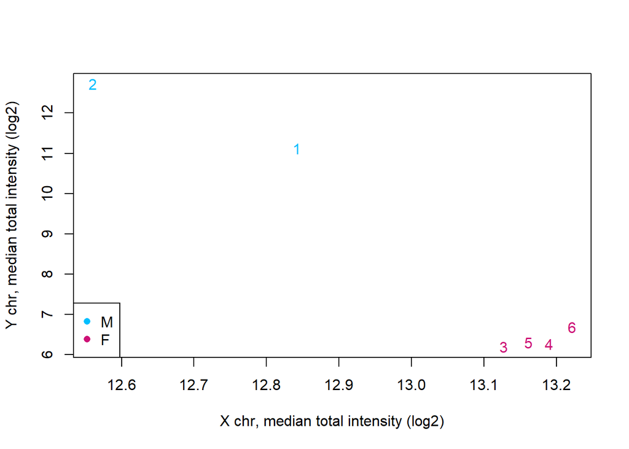

```r
colData(mset) <- getSex(mset)
plotSex(mset)
```

If we look at the graph quickly, we find out that based on the total methylation intensities on the X and Y chromosomes, the make samples are up in light blue while the females are down in red. WE predict that two samples are males and the other 4 are females.

#### QC

It gives numbers that can be used to get the quality of the array. It can help us detect outlier points and flag them out.

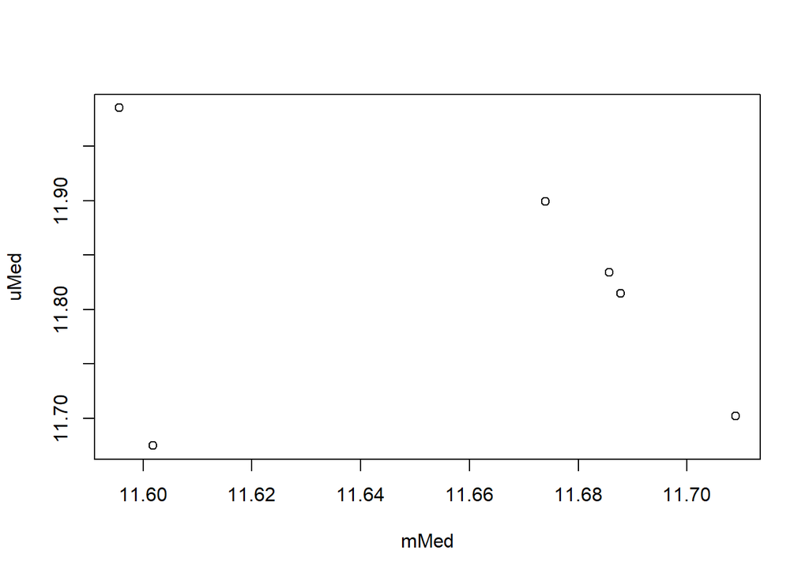

```r
plot(as.matrix(getQC(mset)))
```